### Metadata

#### Description

**Dataset name**: dataset

The dataset has N=180 rows and 68 columns. 180 rows have no missing values on any column.

**Metadata for search engines**

- **Date published**: 2019-05-05
  - **keywords**: *activity*, *subject*, *time Body Accelerometer -mean()-X*, *time Body Accelerometer -mean()-Y*, *time Body Accelerometer -mean()-Z*, *time Body Accelerometer -std()-X*, *time Body Accelerometer -std()-Y*, *time Body Accelerometer -std()-Z*, *time Gravity Accelerometer -mean()-X*, *time Gravity Accelerometer -mean()-Y*, *time Gravity Accelerometer -mean()-Z*, *time Gravity Accelerometer -std()-X*, *time Gravity Accelerometer -std()-Y*, *time Gravity Accelerometer -std()-Z*, *time Body Accelerometer Jerk-mean()-X*, *time Body Accelerometer Jerk-mean()-Y*, *time Body Accelerometer Jerk-mean()-Z*, *time Body Accelerometer Jerk-std()-X*, *time Body Accelerometer Jerk-std()-Y*, *time Body Accelerometer Jerk-std()-Z*, *time Body Gyroscope -mean()-X*, *time Body Gyroscope -mean()-Y*, *time Body Gyroscope -mean()-Z*, *time Body Gyroscope -std()-X*, *time Body Gyroscope -std()-Y*, *time Body Gyroscope -std()-Z*, *time Body Gyroscope Jerk-mean()-X*, *time Body Gyroscope Jerk-mean()-Y*, *time Body Gyroscope Jerk-mean()-Z*, *time Body Gyroscope Jerk-std()-X*, *time Body Gyroscope Jerk-std()-Y*, *time Body Gyroscope Jerk-std()-Z*, *time Body Accelerometer Magnitude -mean()*, *time Body Accelerometer Magnitude -std()*, *time Gravity Accelerometer Magnitude -mean()*, *time Gravity Accelerometer Magnitude -std()*, *time Body Accelerometer JerkMagnitude -mean()*, *time Body Accelerometer JerkMagnitude -std()*, *time Body Gyroscope Magnitude -mean()*, *time Body Gyroscope Magnitude -std()*, *time Body Gyroscope JerkMagnitude -mean()*, *time Body Gyroscope JerkMagnitude -std()*, *frequency Body Accelerometer -mean()-X*, *frequency Body Accelerometer -mean()-Y*, *frequency Body Accelerometer -mean()-Z*, *frequency Body Accelerometer -std()-X*, *frequency Body Accelerometer -std()-Y*, *frequency Body Accelerometer -std()-Z*, *frequency Body Accelerometer Jerk-mean()-X*, *frequency Body Accelerometer Jerk-mean()-Y*, *frequency Body Accelerometer Jerk-mean()-Z*, *frequency Body Accelerometer Jerk-std()-X*, *frequency Body Accelerometer Jerk-std()-Y*, *frequency Body Accelerometer Jerk-std()-Z*, *frequency Body Gyroscope -mean()-X*, *frequency Body Gyroscope -mean()-Y*, *frequency Body Gyroscope -mean()-Z*, *frequency Body Gyroscope -std()-X*, *frequency Body Gyroscope -std()-Y*, *frequency Body Gyroscope -std()-Z*, *frequency Body Accelerometer Magnitude -mean()*, *frequency Body Accelerometer Magnitude -std()*, *frequency BodyBody Accelerometer JerkMagnitude -mean()*, *frequency BodyBody Accelerometer JerkMagnitude -std()*, *frequency BodyBody Gyroscope Magnitude -mean()*, *frequency BodyBody Gyroscope Magnitude -std()*, *frequency BodyBody Gyroscope JerkMagnitude -mean()* and *frequency BodyBody Gyroscope JerkMagnitude -std()*

## Variables

### activity

#### Distribution

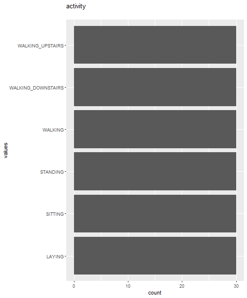

0 missing values.

#### Summary statistics

| name | data_type | missing | complete | n | empty | n_unique | min | max |
| --- | --- | --- | --- | --- | --- | --- | --- | --- |
| activity | character | 0 | 180 | 180 | 0 | 6 | 6 | 18 |

### subject

#### Distribution

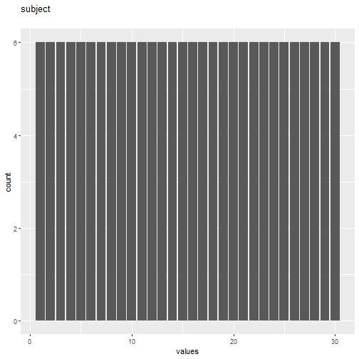

0 missing values.

#### Summary statistics

| name | data_type | missing | complete | n | mean | sd | p0 | p25 | p50 | p75 | p100 | hist |
| --- | --- | --- | --- | --- | --- | --- | --- | --- | --- | --- | --- | --- |
| subject | integer | 0 | 180 | 180 | 15.5 | 8.68 | 1 | 8 | 15.5 | 23 | 30 | ▇▇▆▇▇▆▇▇ |

### time Body Accelerometer -mean()-X

#### Distribution

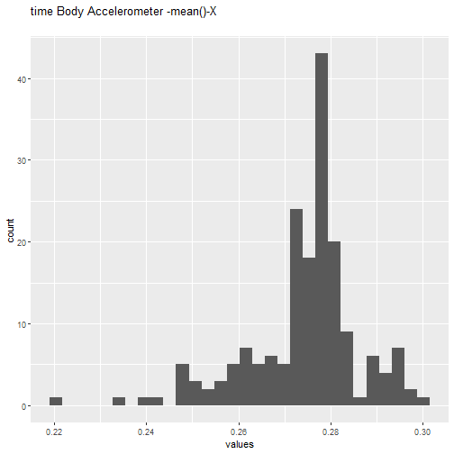

0 missing values.

#### Summary statistics

| name | data_type | missing | complete | n | mean | sd | p0 | p25 | p50 | p75 | p100 | hist |
| --- | --- | --- | --- | --- | --- | --- | --- | --- | --- | --- | --- | --- |
| time Body Accelerometer -mean()-X | numeric | 0 | 180 | 180 | 0.27 | 0.012 | 0.22 | 0.27 | 0.28 | 0.28 | 0.3 | ▁▁▁▁▂▇▂▁ |

### time Body Accelerometer -mean()-Y

#### Distribution

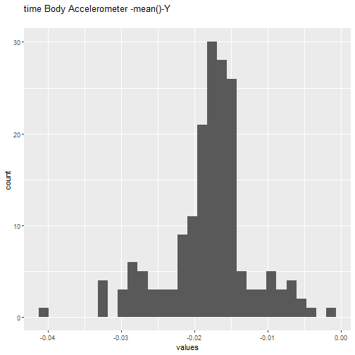

0 missing values.

#### Summary statistics

| name | data_type | missing | complete | n | mean | sd | p0 | p25 | p50 | p75 | p100 | hist |
| --- | --- | --- | --- | --- | --- | --- | --- | --- | --- | --- | --- | --- |
| time Body Accelerometer -mean()-Y | numeric | 0 | 180 | 180 | -0.018 | 0.0058 | -0.041 | -0.02 | -0.017 | -0.015 | -0.0013 | ▁▁▂▂▇▃▁▁ |

### time Body Accelerometer -mean()-Z

#### Distribution

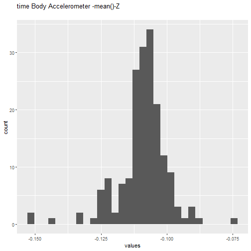

0 missing values.

#### Summary statistics

| name | data_type | missing | complete | n | mean | sd | p0 | p25 | p50 | p75 | p100 | hist |
| --- | --- | --- | --- | --- | --- | --- | --- | --- | --- | --- | --- | --- |
| time Body Accelerometer -mean()-Z | numeric | 0 | 180 | 180 | -0.11 | 0.0096 | -0.15 | -0.11 | -0.11 | -0.1 | -0.075 | ▁▁▁▂▇▃▁▁ |

### time Body Accelerometer -std()-X

#### Distribution

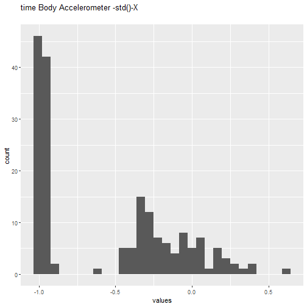

0 missing values.

#### Summary statistics

| name | data_type | missing | complete | n | mean | sd | p0 | p25 | p50 | p75 | p100 | hist |
| --- | --- | --- | --- | --- | --- | --- | --- | --- | --- | --- | --- | --- |
| time Body Accelerometer -std()-X | numeric | 0 | 180 | 180 | -0.56 | 0.45 | -1 | -0.98 | -0.75 | -0.2 | 0.63 | ▇▁▁▃▂▂▁▁ |

### time Body Accelerometer -std()-Y

#### Distribution

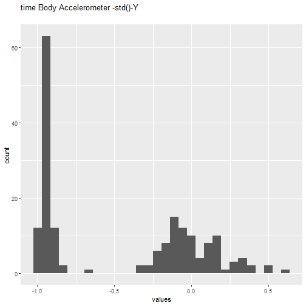

0 missing values.

#### Summary statistics

| name | data_type | missing | complete | n | mean | sd | p0 | p25 | p50 | p75 | p100 | hist |
| --- | --- | --- | --- | --- | --- | --- | --- | --- | --- | --- | --- | --- |
| time Body Accelerometer -std()-Y | numeric | 0 | 180 | 180 | -0.46 | 0.5 | -0.99 | -0.94 | -0.51 | -0.031 | 0.62 | ▇▁▁▁▃▂▁▁ |

### time Body Accelerometer -std()-Z

#### Distribution

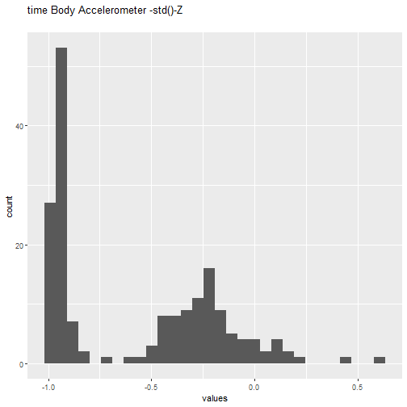

0 missing values.

#### Summary statistics

| name | data_type | missing | complete | n | mean | sd | p0 | p25 | p50 | p75 | p100 | hist |
| --- | --- | --- | --- | --- | --- | --- | --- | --- | --- | --- | --- | --- |
| time Body Accelerometer -std()-Z | numeric | 0 | 180 | 180 | -0.58 | 0.4 | -0.99 | -0.95 | -0.65 | -0.23 | 0.61 | ▇▁▂▃▂▁▁▁ |

### time Gravity Accelerometer -mean()-X

#### Distribution

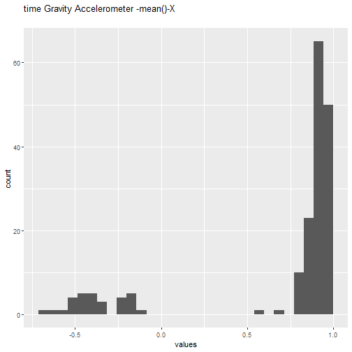

0 missing values.

#### Summary statistics

| name | data_type | missing | complete | n | mean | sd | p0 | p25 | p50 | p75 | p100 | hist |
| --- | --- | --- | --- | --- | --- | --- | --- | --- | --- | --- | --- | --- |
| time Gravity Accelerometer -mean()-X | numeric | 0 | 180 | 180 | 0.7 | 0.49 | -0.68 | 0.84 | 0.92 | 0.94 | 0.97 | ▁▁▁▁▁▁▁▇ |

### time Gravity Accelerometer -mean()-Y

#### Distribution

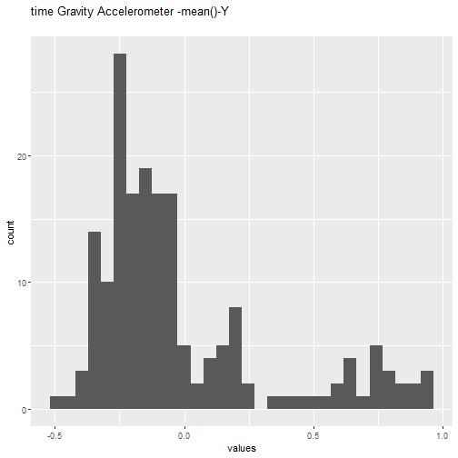

0 missing values.

#### Summary statistics

| name | data_type | missing | complete | n | mean | sd | p0 | p25 | p50 | p75 | p100 | hist |
| --- | --- | --- | --- | --- | --- | --- | --- | --- | --- | --- | --- | --- |
| time Gravity Accelerometer -mean()-Y | numeric | 0 | 180 | 180 | -0.016 | 0.35 | -0.48 | -0.23 | -0.13 | 0.088 | 0.96 | ▂▇▅▂▁▁▁▁ |

### time Gravity Accelerometer -mean()-Z

#### Distribution

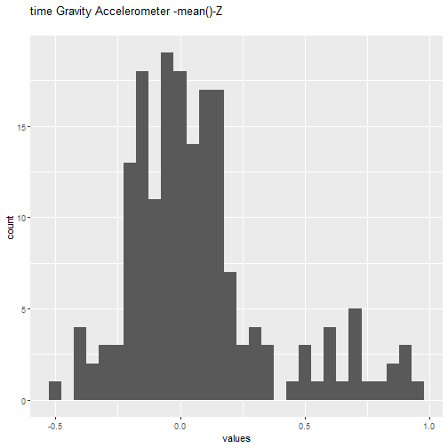

0 missing values.

#### Summary statistics

| name | data_type | missing | complete | n | mean | sd | p0 | p25 | p50 | p75 | p100 | hist |
| --- | --- | --- | --- | --- | --- | --- | --- | --- | --- | --- | --- | --- |
| time Gravity Accelerometer -mean()-Z | numeric | 0 | 180 | 180 | 0.074 | 0.29 | -0.5 | -0.12 | 0.024 | 0.15 | 0.96 | ▁▅▇▆▁▁▁▁ |

### time Gravity Accelerometer -std()-X

#### Distribution

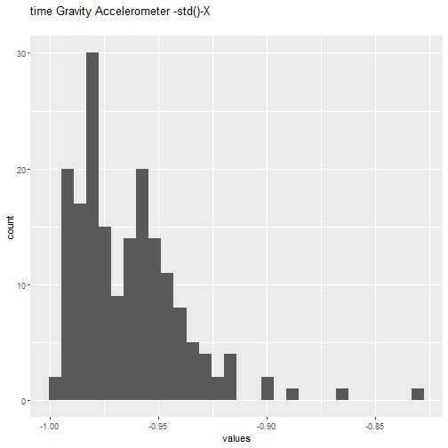

0 missing values.

#### Summary statistics

| name | data_type | missing | complete | n | mean | sd | p0 | p25 | p50 | p75 | p100 | hist |
| --- | --- | --- | --- | --- | --- | --- | --- | --- | --- | --- | --- | --- |
| time Gravity Accelerometer -std()-X | numeric | 0 | 180 | 180 | -0.96 | 0.025 | -1 | -0.98 | -0.97 | -0.95 | -0.83 | ▇▆▅▂▁▁▁▁ |

### time Gravity Accelerometer -std()-Y

#### Distribution

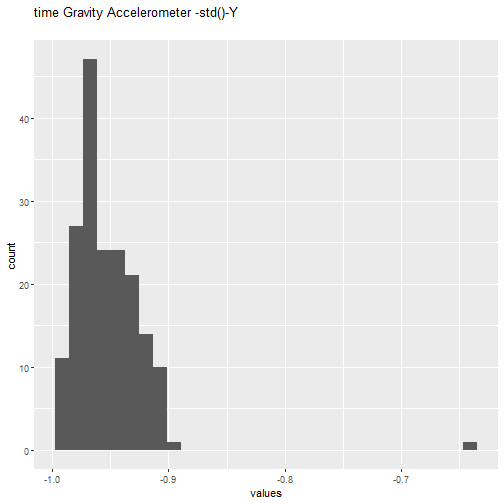

0 missing values.

#### Summary statistics

| name | data_type | missing | complete | n | mean | sd | p0 | p25 | p50 | p75 | p100 | hist |
| --- | --- | --- | --- | --- | --- | --- | --- | --- | --- | --- | --- | --- |
| time Gravity Accelerometer -std()-Y | numeric | 0 | 180 | 180 | -0.95 | 0.033 | -0.99 | -0.97 | -0.96 | -0.94 | -0.64 | ▇▅▁▁▁▁▁▁ |

### time Gravity Accelerometer -std()-Z

#### Distribution

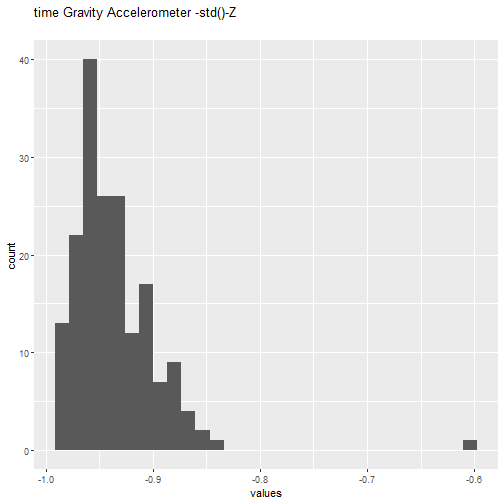

0 missing values.

#### Summary statistics

| name | data_type | missing | complete | n | mean | sd | p0 | p25 | p50 | p75 | p100 | hist |
| --- | --- | --- | --- | --- | --- | --- | --- | --- | --- | --- | --- | --- |
| time Gravity Accelerometer -std()-Z | numeric | 0 | 180 | 180 | -0.94 | 0.04 | -0.99 | -0.96 | -0.95 | -0.92 | -0.61 | ▇▆▂▁▁▁▁▁ |

### time Body Accelerometer Jerk-mean()-X

#### Distribution

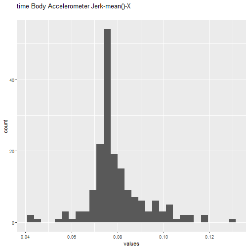

0 missing values.

#### Summary statistics

| name | data_type | missing | complete | n | mean | sd | p0 | p25 | p50 | p75 | p100 | hist |
| --- | --- | --- | --- | --- | --- | --- | --- | --- | --- | --- | --- | --- |
| time Body Accelerometer Jerk-mean()-X | numeric | 0 | 180 | 180 | 0.079 | 0.013 | 0.043 | 0.074 | 0.076 | 0.083 | 0.13 | ▁▁▇▇▂▁▁▁ |

### time Body Accelerometer Jerk-mean()-Y

#### Distribution

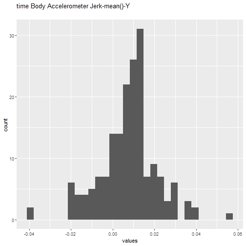

0 missing values.

#### Summary statistics

| name | data_type | missing | complete | n | mean | sd | p0 | p25 | p50 | p75 | p100 | hist |
| --- | --- | --- | --- | --- | --- | --- | --- | --- | --- | --- | --- | --- |
| time Body Accelerometer Jerk-mean()-Y | numeric | 0 | 180 | 180 | 0.0076 | 0.014 | -0.039 | 0.00047 | 0.0095 | 0.013 | 0.057 | ▁▁▂▆▇▂▁▁ |

### time Body Accelerometer Jerk-mean()-Z

#### Distribution

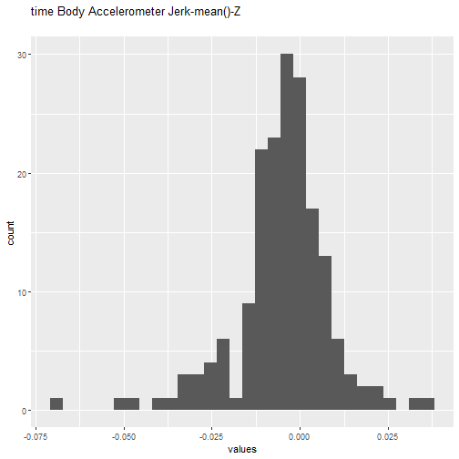

0 missing values.

#### Summary statistics

| name | data_type | missing | complete | n | mean | sd | p0 | p25 | p50 | p75 | p100 | hist |
| --- | --- | --- | --- | --- | --- | --- | --- | --- | --- | --- | --- | --- |
| time Body Accelerometer Jerk-mean()-Z | numeric | 0 | 180 | 180 | -0.005 | 0.013 | -0.067 | -0.011 | -0.0039 | 0.002 | 0.038 | ▁▁▁▁▇▆▁▁ |

### time Body Accelerometer Jerk-std()-X

#### Distribution

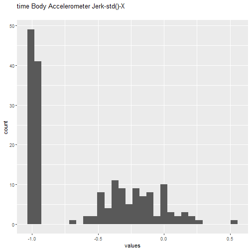

0 missing values.

#### Summary statistics

| name | data_type | missing | complete | n | mean | sd | p0 | p25 | p50 | p75 | p100 | hist |
| --- | --- | --- | --- | --- | --- | --- | --- | --- | --- | --- | --- | --- |
| time Body Accelerometer Jerk-std()-X | numeric | 0 | 180 | 180 | -0.59 | 0.42 | -0.99 | -0.98 | -0.81 | -0.22 | 0.54 | ▇▁▁▂▂▂▁▁ |

### time Body Accelerometer Jerk-std()-Y

#### Distribution

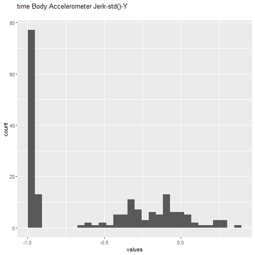

0 missing values.

#### Summary statistics

| name | data_type | missing | complete | n | mean | sd | p0 | p25 | p50 | p75 | p100 | hist |
| --- | --- | --- | --- | --- | --- | --- | --- | --- | --- | --- | --- | --- |
| time Body Accelerometer Jerk-std()-Y | numeric | 0 | 180 | 180 | -0.57 | 0.43 | -0.99 | -0.97 | -0.78 | -0.15 | 0.36 | ▇▁▁▂▂▂▁▁ |

### time Body Accelerometer Jerk-std()-Z

#### Distribution

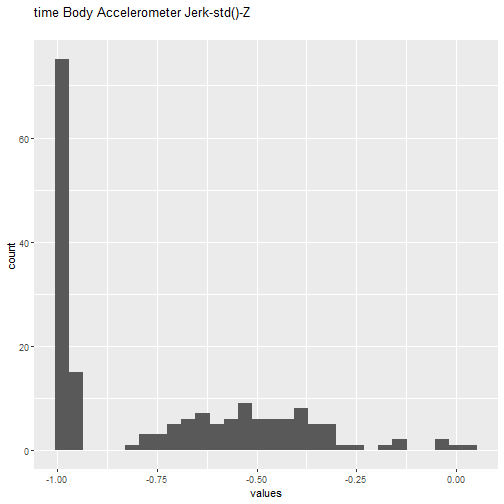

0 missing values.

#### Summary statistics

| name | data_type | missing | complete | n | mean | sd | p0 | p25 | p50 | p75 | p100 | hist |
| --- | --- | --- | --- | --- | --- | --- | --- | --- | --- | --- | --- | --- |
| time Body Accelerometer Jerk-std()-Z | numeric | 0 | 180 | 180 | -0.74 | 0.28 | -0.99 | -0.98 | -0.88 | -0.51 | 0.031 | ▇▁▂▂▂▁▁▁ |

### time Body Gyroscope -mean()-X

#### Distribution

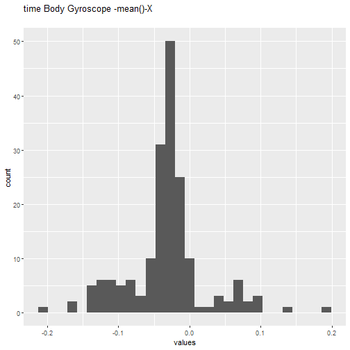

0 missing values.

#### Summary statistics

| name | data_type | missing | complete | n | mean | sd | p0 | p25 | p50 | p75 | p100 | hist |
| --- | --- | --- | --- | --- | --- | --- | --- | --- | --- | --- | --- | --- |
| time Body Gyroscope -mean()-X | numeric | 0 | 180 | 180 | -0.032 | 0.054 | -0.21 | -0.047 | -0.029 | -0.017 | 0.19 | ▁▁▂▇▁▁▁▁ |

### time Body Gyroscope -mean()-Y

#### Distribution

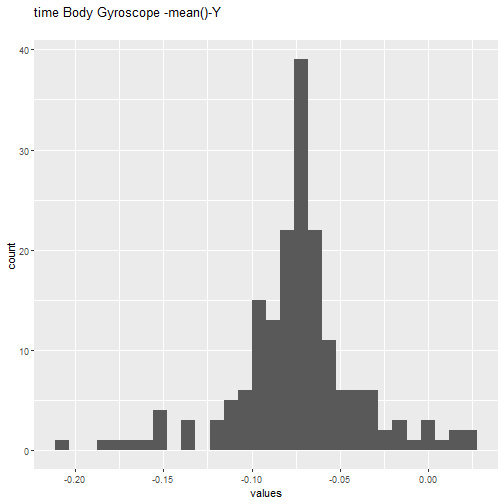

0 missing values.

#### Summary statistics

| name | data_type | missing | complete | n | mean | sd | p0 | p25 | p50 | p75 | p100 | hist |
| --- | --- | --- | --- | --- | --- | --- | --- | --- | --- | --- | --- | --- |
| time Body Gyroscope -mean()-Y | numeric | 0 | 180 | 180 | -0.074 | 0.036 | -0.2 | -0.09 | -0.073 | -0.061 | 0.027 | ▁▁▁▃▇▂▁▁ |

### time Body Gyroscope -mean()-Z

#### Distribution

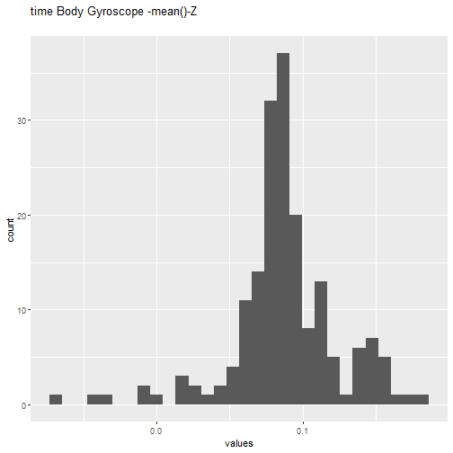

0 missing values.

#### Summary statistics

| name | data_type | missing | complete | n | mean | sd | p0 | p25 | p50 | p75 | p100 | hist |
| --- | --- | --- | --- | --- | --- | --- | --- | --- | --- | --- | --- | --- |
| time Body Gyroscope -mean()-Z | numeric | 0 | 180 | 180 | 0.087 | 0.036 | -0.072 | 0.075 | 0.085 | 0.1 | 0.18 | ▁▁▁▁▇▇▂▁ |

### time Body Gyroscope -std()-X

#### Distribution

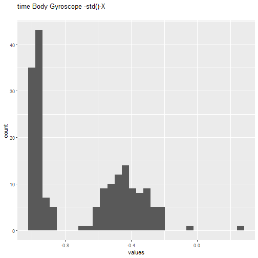

0 missing values.

#### Summary statistics

| name | data_type | missing | complete | n | mean | sd | p0 | p25 | p50 | p75 | p100 | hist |
| --- | --- | --- | --- | --- | --- | --- | --- | --- | --- | --- | --- | --- |
| time Body Gyroscope -std()-X | numeric | 0 | 180 | 180 | -0.69 | 0.29 | -0.99 | -0.97 | -0.79 | -0.44 | 0.27 | ▇▁▂▃▂▁▁▁ |

### time Body Gyroscope -std()-Y

#### Distribution

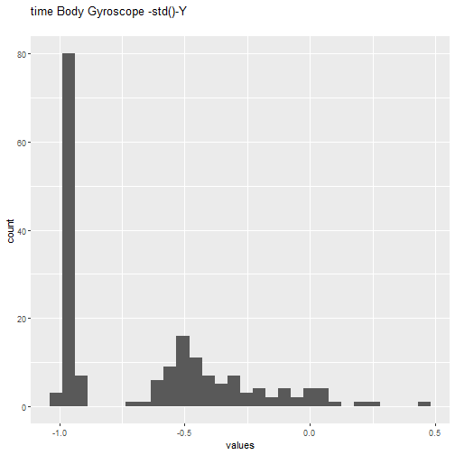

0 missing values.

#### Summary statistics

| name | data_type | missing | complete | n | mean | sd | p0 | p25 | p50 | p75 | p100 | hist |
| --- | --- | --- | --- | --- | --- | --- | --- | --- | --- | --- | --- | --- |
| time Body Gyroscope -std()-Y | numeric | 0 | 180 | 180 | -0.65 | 0.35 | -0.99 | -0.96 | -0.8 | -0.42 | 0.48 | ▇▁▃▂▁▁▁▁ |

### time Body Gyroscope -std()-Z

#### Distribution

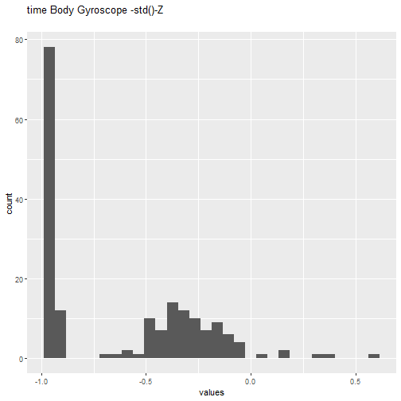

0 missing values.

#### Summary statistics

| name | data_type | missing | complete | n | mean | sd | p0 | p25 | p50 | p75 | p100 | hist |
| --- | --- | --- | --- | --- | --- | --- | --- | --- | --- | --- | --- | --- |
| time Body Gyroscope -std()-Z | numeric | 0 | 180 | 180 | -0.62 | 0.37 | -0.99 | -0.96 | -0.8 | -0.31 | 0.56 | ▇▁▂▃▂▁▁▁ |

### time Body Gyroscope Jerk-mean()-X

#### Distribution

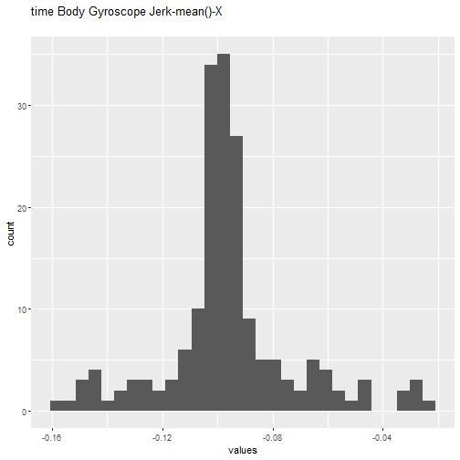

0 missing values.

#### Summary statistics

| name | data_type | missing | complete | n | mean | sd | p0 | p25 | p50 | p75 | p100 | hist |
| --- | --- | --- | --- | --- | --- | --- | --- | --- | --- | --- | --- | --- |
| time Body Gyroscope Jerk-mean()-X | numeric | 0 | 180 | 180 | -0.096 | 0.023 | -0.16 | -0.1 | -0.099 | -0.091 | -0.022 | ▁▁▁▇▁▁▁▁ |

### time Body Gyroscope Jerk-mean()-Y

#### Distribution

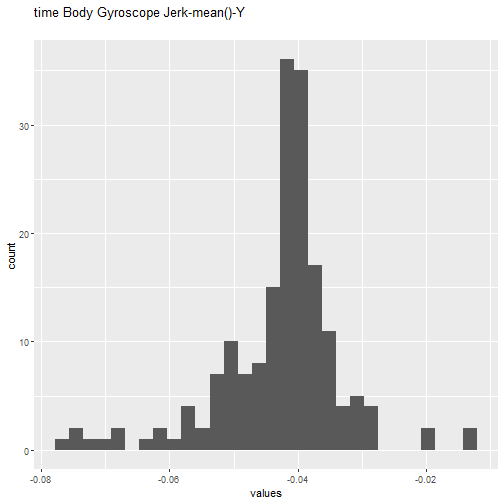

0 missing values.

#### Summary statistics

| name | data_type | missing | complete | n | mean | sd | p0 | p25 | p50 | p75 | p100 | hist |
| --- | --- | --- | --- | --- | --- | --- | --- | --- | --- | --- | --- | --- |
| time Body Gyroscope Jerk-mean()-Y | numeric | 0 | 180 | 180 | -0.043 | 0.0095 | -0.077 | -0.046 | -0.041 | -0.038 | -0.013 | ▁▁▁▂▇▂▁▁ |

### time Body Gyroscope Jerk-mean()-Z

#### Distribution

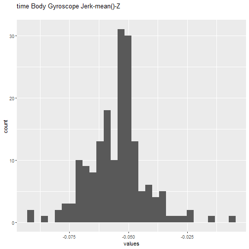

0 missing values.

#### Summary statistics

| name | data_type | missing | complete | n | mean | sd | p0 | p25 | p50 | p75 | p100 | hist |
| --- | --- | --- | --- | --- | --- | --- | --- | --- | --- | --- | --- | --- |
| time Body Gyroscope Jerk-mean()-Z | numeric | 0 | 180 | 180 | -0.055 | 0.012 | -0.092 | -0.062 | -0.053 | -0.049 | -0.0069 | ▁▁▃▇▃▁▁▁ |

### time Body Gyroscope Jerk-std()-X

#### Distribution

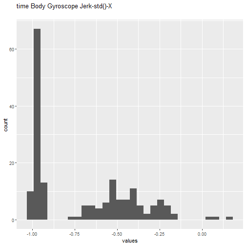

0 missing values.

#### Summary statistics

| name | data_type | missing | complete | n | mean | sd | p0 | p25 | p50 | p75 | p100 | hist |
| --- | --- | --- | --- | --- | --- | --- | --- | --- | --- | --- | --- | --- |
| time Body Gyroscope Jerk-std()-X | numeric | 0 | 180 | 180 | -0.7 | 0.3 | -1 | -0.98 | -0.84 | -0.46 | 0.18 | ▇▁▂▃▂▁▁▁ |

### time Body Gyroscope Jerk-std()-Y

#### Distribution

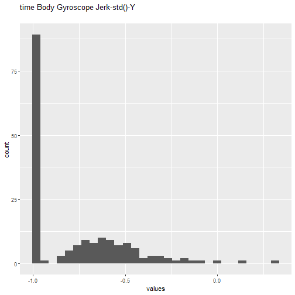

0 missing values.

#### Summary statistics

| name | data_type | missing | complete | n | mean | sd | p0 | p25 | p50 | p75 | p100 | hist |
| --- | --- | --- | --- | --- | --- | --- | --- | --- | --- | --- | --- | --- |
| time Body Gyroscope Jerk-std()-Y | numeric | 0 | 180 | 180 | -0.76 | 0.27 | -1 | -0.98 | -0.89 | -0.59 | 0.3 | ▇▂▂▂▁▁▁▁ |

### time Body Gyroscope Jerk-std()-Z

#### Distribution

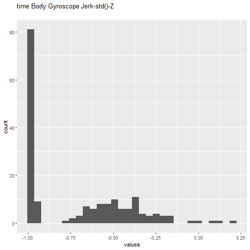

0 missing values.

#### Summary statistics

| name | data_type | missing | complete | n | mean | sd | p0 | p25 | p50 | p75 | p100 | hist |
| --- | --- | --- | --- | --- | --- | --- | --- | --- | --- | --- | --- | --- |
| time Body Gyroscope Jerk-std()-Z | numeric | 0 | 180 | 180 | -0.71 | 0.3 | -1 | -0.98 | -0.86 | -0.47 | 0.19 | ▇▁▂▂▂▁▁▁ |

### time Body Accelerometer Magnitude -mean()

#### Distribution

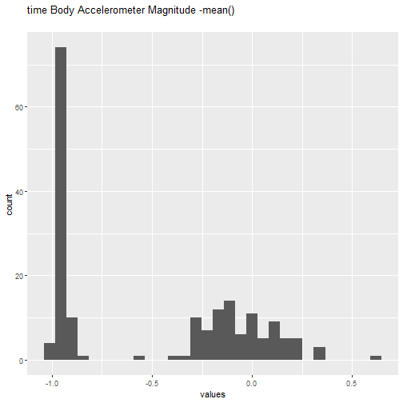

0 missing values.

#### Summary statistics

| name | data_type | missing | complete | n | mean | sd | p0 | p25 | p50 | p75 | p100 | hist |
| --- | --- | --- | --- | --- | --- | --- | --- | --- | --- | --- | --- | --- |
| time Body Accelerometer Magnitude -mean() | numeric | 0 | 180 | 180 | -0.5 | 0.47 | -0.99 | -0.96 | -0.48 | -0.092 | 0.64 | ▇▁▁▂▃▂▁▁ |

### time Body Accelerometer Magnitude -std()

#### Distribution

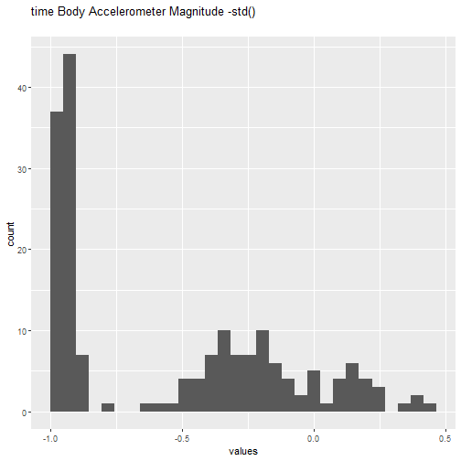

0 missing values.

#### Summary statistics

| name | data_type | missing | complete | n | mean | sd | p0 | p25 | p50 | p75 | p100 | hist |
| --- | --- | --- | --- | --- | --- | --- | --- | --- | --- | --- | --- | --- |
| time Body Accelerometer Magnitude -std() | numeric | 0 | 180 | 180 | -0.54 | 0.43 | -0.99 | -0.94 | -0.61 | -0.21 | 0.43 | ▇▁▁▂▂▁▂▁ |

### time Gravity Accelerometer Magnitude -mean()

#### Distribution

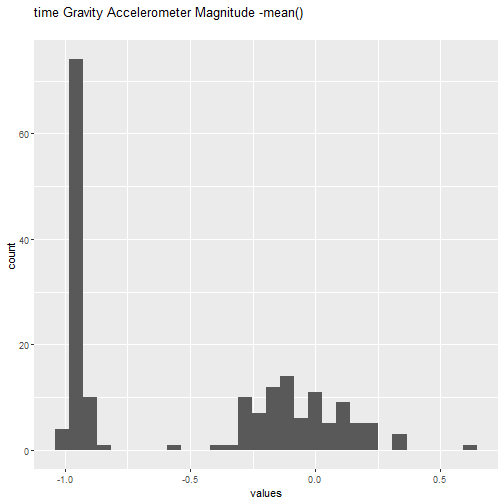

0 missing values.

#### Summary statistics

| name | data_type | missing | complete | n | mean | sd | p0 | p25 | p50 | p75 | p100 | hist |
| --- | --- | --- | --- | --- | --- | --- | --- | --- | --- | --- | --- | --- |
| time Gravity Accelerometer Magnitude -mean() | numeric | 0 | 180 | 180 | -0.5 | 0.47 | -0.99 | -0.96 | -0.48 | -0.092 | 0.64 | ▇▁▁▂▃▂▁▁ |

### time Gravity Accelerometer Magnitude -std()

#### Distribution

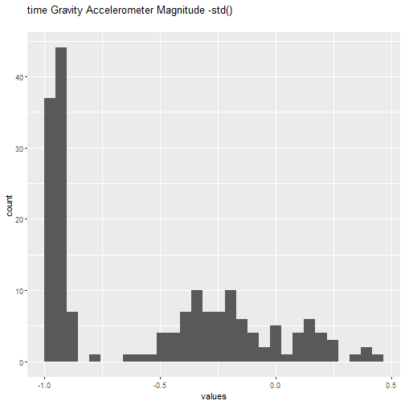

0 missing values.

#### Summary statistics

| name | data_type | missing | complete | n | mean | sd | p0 | p25 | p50 | p75 | p100 | hist |
| --- | --- | --- | --- | --- | --- | --- | --- | --- | --- | --- | --- | --- |
| time Gravity Accelerometer Magnitude -std() | numeric | 0 | 180 | 180 | -0.54 | 0.43 | -0.99 | -0.94 | -0.61 | -0.21 | 0.43 | ▇▁▁▂▂▁▂▁ |

### time Body Accelerometer JerkMagnitude -mean()

#### Distribution

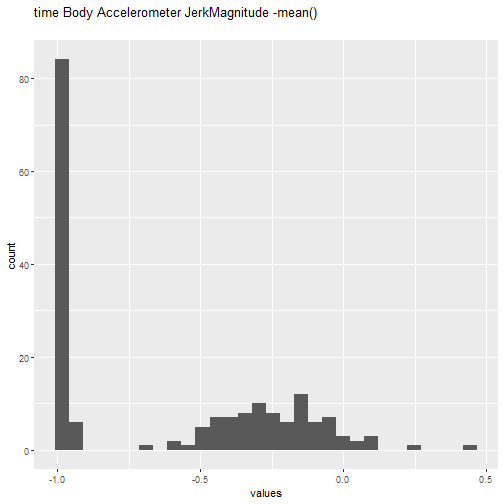

0 missing values.

#### Summary statistics

| name | data_type | missing | complete | n | mean | sd | p0 | p25 | p50 | p75 | p100 | hist |
| --- | --- | --- | --- | --- | --- | --- | --- | --- | --- | --- | --- | --- |
| time Body Accelerometer JerkMagnitude -mean() | numeric | 0 | 180 | 180 | -0.61 | 0.4 | -0.99 | -0.98 | -0.82 | -0.25 | 0.43 | ▇▁▁▂▂▁▁▁ |

### time Body Accelerometer JerkMagnitude -std()

#### Distribution

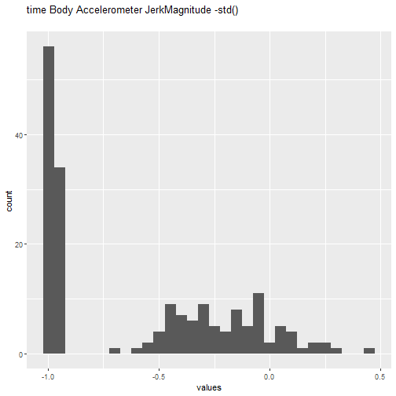

0 missing values.

#### Summary statistics

| name | data_type | missing | complete | n | mean | sd | p0 | p25 | p50 | p75 | p100 | hist |
| --- | --- | --- | --- | --- | --- | --- | --- | --- | --- | --- | --- | --- |
| time Body Accelerometer JerkMagnitude -std() | numeric | 0 | 180 | 180 | -0.58 | 0.42 | -0.99 | -0.98 | -0.8 | -0.22 | 0.45 | ▇▁▁▂▂▂▁▁ |

### time Body Gyroscope Magnitude -mean()

#### Distribution

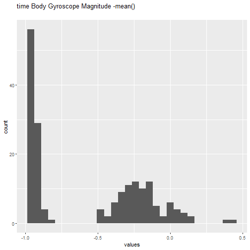

0 missing values.

#### Summary statistics

| name | data_type | missing | complete | n | mean | sd | p0 | p25 | p50 | p75 | p100 | hist |
| --- | --- | --- | --- | --- | --- | --- | --- | --- | --- | --- | --- | --- |
| time Body Gyroscope Magnitude -mean() | numeric | 0 | 180 | 180 | -0.57 | 0.4 | -0.98 | -0.95 | -0.66 | -0.22 | 0.42 | ▇▁▁▂▃▁▁▁ |

### time Body Gyroscope Magnitude -std()

#### Distribution

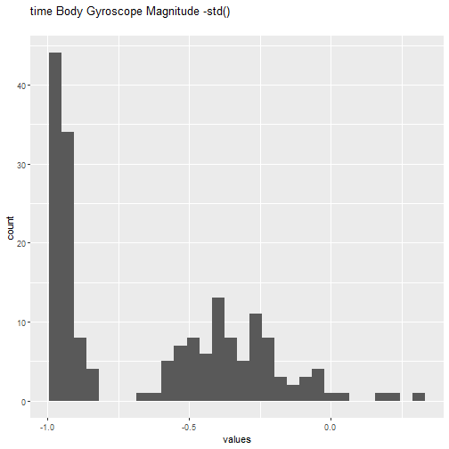

0 missing values.

#### Summary statistics

| name | data_type | missing | complete | n | mean | sd | p0 | p25 | p50 | p75 | p100 | hist |
| --- | --- | --- | --- | --- | --- | --- | --- | --- | --- | --- | --- | --- |
| time Body Gyroscope Magnitude -std() | numeric | 0 | 180 | 180 | -0.63 | 0.34 | -0.98 | -0.95 | -0.74 | -0.36 | 0.3 | ▇▁▂▃▂▁▁▁ |

### time Body Gyroscope JerkMagnitude -mean()

#### Distribution

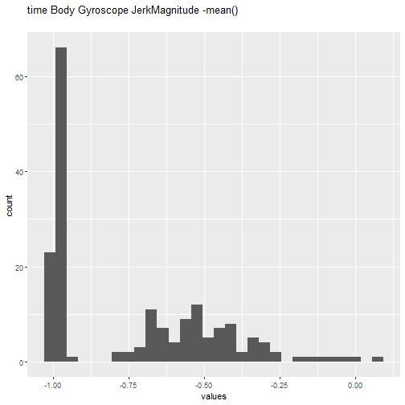

0 missing values.

#### Summary statistics

| name | data_type | missing | complete | n | mean | sd | p0 | p25 | p50 | p75 | p100 | hist |
| --- | --- | --- | --- | --- | --- | --- | --- | --- | --- | --- | --- | --- |
| time Body Gyroscope JerkMagnitude -mean() | numeric | 0 | 180 | 180 | -0.74 | 0.28 | -1 | -0.99 | -0.86 | -0.51 | 0.088 | ▇▁▂▂▂▁▁▁ |

### time Body Gyroscope JerkMagnitude -std()

#### Distribution

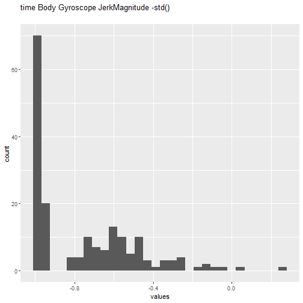

0 missing values.

#### Summary statistics

| name | data_type | missing | complete | n | mean | sd | p0 | p25 | p50 | p75 | p100 | hist |
| --- | --- | --- | --- | --- | --- | --- | --- | --- | --- | --- | --- | --- |
| time Body Gyroscope JerkMagnitude -std() | numeric | 0 | 180 | 180 | -0.76 | 0.27 | -1 | -0.98 | -0.88 | -0.58 | 0.25 | ▇▂▃▂▁▁▁▁ |

### frequency Body Accelerometer -mean()-X

#### Distribution

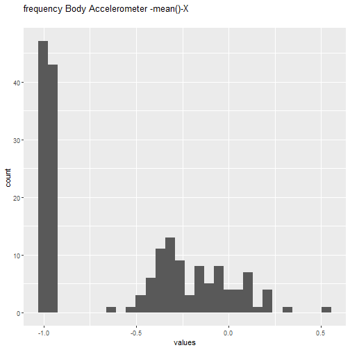

0 missing values.

#### Summary statistics

| name | data_type | missing | complete | n | mean | sd | p0 | p25 | p50 | p75 | p100 | hist |
| --- | --- | --- | --- | --- | --- | --- | --- | --- | --- | --- | --- | --- |
| frequency Body Accelerometer -mean()-X | numeric | 0 | 180 | 180 | -0.58 | 0.43 | -1 | -0.98 | -0.77 | -0.22 | 0.54 | ▇▁▁▃▂▂▁▁ |

### frequency Body Accelerometer -mean()-Y

#### Distribution

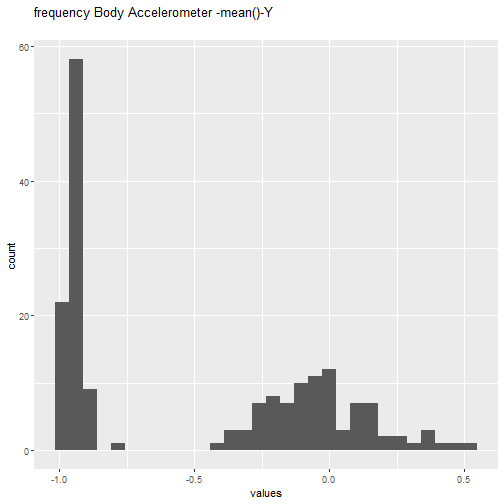

0 missing values.

#### Summary statistics

| name | data_type | missing | complete | n | mean | sd | p0 | p25 | p50 | p75 | p100 | hist |
| --- | --- | --- | --- | --- | --- | --- | --- | --- | --- | --- | --- | --- |
| frequency Body Accelerometer -mean()-Y | numeric | 0 | 180 | 180 | -0.49 | 0.48 | -0.99 | -0.95 | -0.59 | -0.063 | 0.52 | ▇▁▁▁▃▂▁▁ |

### frequency Body Accelerometer -mean()-Z

#### Distribution

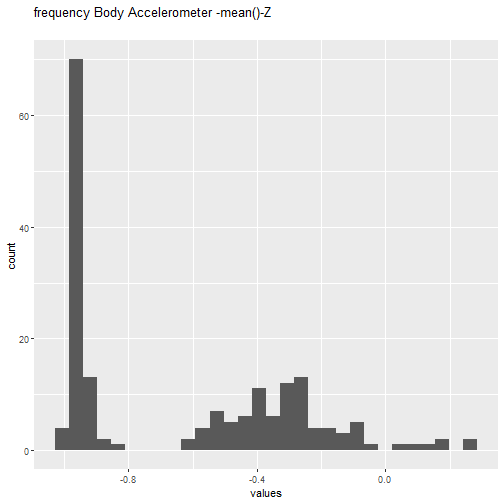

0 missing values.

#### Summary statistics

| name | data_type | missing | complete | n | mean | sd | p0 | p25 | p50 | p75 | p100 | hist |
| --- | --- | --- | --- | --- | --- | --- | --- | --- | --- | --- | --- | --- |
| frequency Body Accelerometer -mean()-Z | numeric | 0 | 180 | 180 | -0.63 | 0.36 | -0.99 | -0.96 | -0.72 | -0.32 | 0.28 | ▇▁▁▂▃▁▁▁ |

### frequency Body Accelerometer -std()-X

#### Distribution

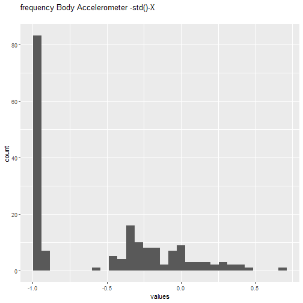

0 missing values.

#### Summary statistics

| name | data_type | missing | complete | n | mean | sd | p0 | p25 | p50 | p75 | p100 | hist |
| --- | --- | --- | --- | --- | --- | --- | --- | --- | --- | --- | --- | --- |
| frequency Body Accelerometer -std()-X | numeric | 0 | 180 | 180 | -0.55 | 0.46 | -1 | -0.98 | -0.75 | -0.2 | 0.66 | ▇▁▁▃▂▁▁▁ |

### frequency Body Accelerometer -std()-Y

#### Distribution

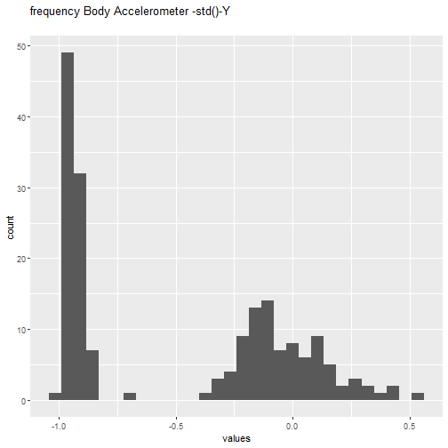

0 missing values.

#### Summary statistics

| name | data_type | missing | complete | n | mean | sd | p0 | p25 | p50 | p75 | p100 | hist |
| --- | --- | --- | --- | --- | --- | --- | --- | --- | --- | --- | --- | --- |
| frequency Body Accelerometer -std()-Y | numeric | 0 | 180 | 180 | -0.48 | 0.47 | -0.99 | -0.94 | -0.51 | -0.079 | 0.56 | ▇▁▁▁▃▂▁▁ |

### frequency Body Accelerometer -std()-Z

#### Distribution

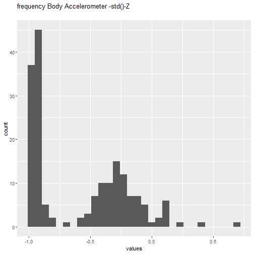

0 missing values.

#### Summary statistics

| name | data_type | missing | complete | n | mean | sd | p0 | p25 | p50 | p75 | p100 | hist |
| --- | --- | --- | --- | --- | --- | --- | --- | --- | --- | --- | --- | --- |
| frequency Body Accelerometer -std()-Z | numeric | 0 | 180 | 180 | -0.58 | 0.39 | -0.99 | -0.95 | -0.64 | -0.27 | 0.69 | ▇▁▂▃▁▁▁▁ |

### frequency Body Accelerometer Jerk-mean()-X

#### Distribution

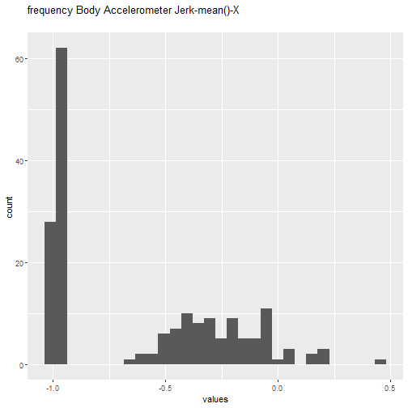

0 missing values.

#### Summary statistics

| name | data_type | missing | complete | n | mean | sd | p0 | p25 | p50 | p75 | p100 | hist |
| --- | --- | --- | --- | --- | --- | --- | --- | --- | --- | --- | --- | --- |
| frequency Body Accelerometer Jerk-mean()-X | numeric | 0 | 180 | 180 | -0.61 | 0.4 | -0.99 | -0.98 | -0.81 | -0.28 | 0.47 | ▇▁▁▂▂▁▁▁ |

### frequency Body Accelerometer Jerk-mean()-Y

#### Distribution

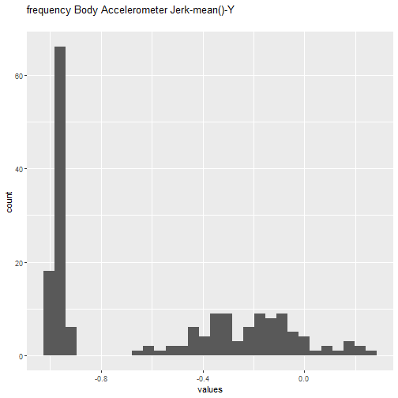

0 missing values.

#### Summary statistics

| name | data_type | missing | complete | n | mean | sd | p0 | p25 | p50 | p75 | p100 | hist |
| --- | --- | --- | --- | --- | --- | --- | --- | --- | --- | --- | --- | --- |
| frequency Body Accelerometer Jerk-mean()-Y | numeric | 0 | 180 | 180 | -0.59 | 0.41 | -0.99 | -0.97 | -0.78 | -0.2 | 0.28 | ▇▁▁▂▂▂▁▁ |

### frequency Body Accelerometer Jerk-mean()-Z

#### Distribution

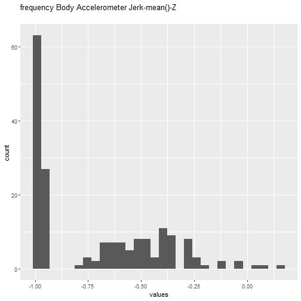

0 missing values.

#### Summary statistics

| name | data_type | missing | complete | n | mean | sd | p0 | p25 | p50 | p75 | p100 | hist |
| --- | --- | --- | --- | --- | --- | --- | --- | --- | --- | --- | --- | --- |
| frequency Body Accelerometer Jerk-mean()-Z | numeric | 0 | 180 | 180 | -0.71 | 0.3 | -0.99 | -0.98 | -0.87 | -0.47 | 0.16 | ▇▁▂▂▂▁▁▁ |

### frequency Body Accelerometer Jerk-std()-X

#### Distribution

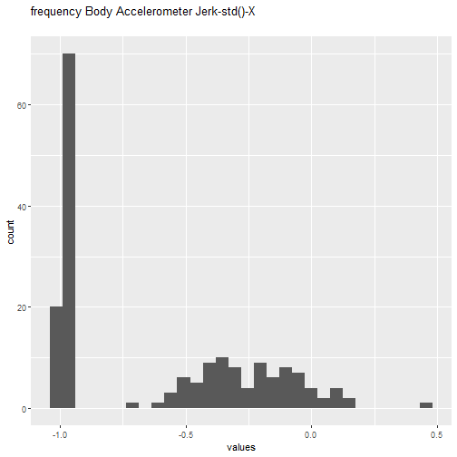

0 missing values.

#### Summary statistics

| name | data_type | missing | complete | n | mean | sd | p0 | p25 | p50 | p75 | p100 | hist |
| --- | --- | --- | --- | --- | --- | --- | --- | --- | --- | --- | --- | --- |
| frequency Body Accelerometer Jerk-std()-X | numeric | 0 | 180 | 180 | -0.61 | 0.4 | -1 | -0.98 | -0.83 | -0.25 | 0.48 | ▇▁▁▂▂▂▁▁ |

### frequency Body Accelerometer Jerk-std()-Y

#### Distribution

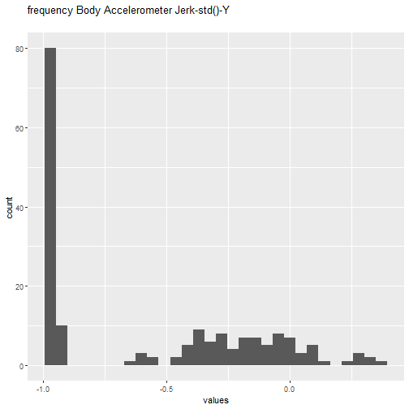

0 missing values.

#### Summary statistics

| name | data_type | missing | complete | n | mean | sd | p0 | p25 | p50 | p75 | p100 | hist |
| --- | --- | --- | --- | --- | --- | --- | --- | --- | --- | --- | --- | --- |
| frequency Body Accelerometer Jerk-std()-Y | numeric | 0 | 180 | 180 | -0.57 | 0.43 | -0.99 | -0.97 | -0.79 | -0.17 | 0.35 | ▇▁▁▂▂▂▁▁ |

### frequency Body Accelerometer Jerk-std()-Z

#### Distribution

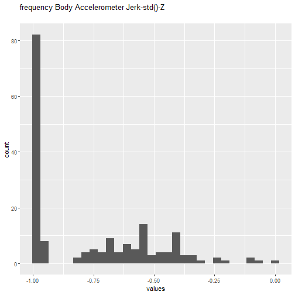

0 missing values.

#### Summary statistics

| name | data_type | missing | complete | n | mean | sd | p0 | p25 | p50 | p75 | p100 | hist |
| --- | --- | --- | --- | --- | --- | --- | --- | --- | --- | --- | --- | --- |
| frequency Body Accelerometer Jerk-std()-Z | numeric | 0 | 180 | 180 | -0.76 | 0.26 | -0.99 | -0.98 | -0.9 | -0.54 | -0.0062 | ▇▁▂▂▂▁▁▁ |

### frequency Body Gyroscope -mean()-X

#### Distribution

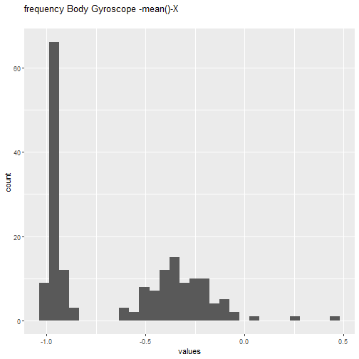

0 missing values.

#### Summary statistics

| name | data_type | missing | complete | n | mean | sd | p0 | p25 | p50 | p75 | p100 | hist |
| --- | --- | --- | --- | --- | --- | --- | --- | --- | --- | --- | --- | --- |
| frequency Body Gyroscope -mean()-X | numeric | 0 | 180 | 180 | -0.64 | 0.35 | -0.99 | -0.97 | -0.73 | -0.34 | 0.47 | ▇▁▂▃▂▁▁▁ |

### frequency Body Gyroscope -mean()-Y

#### Distribution

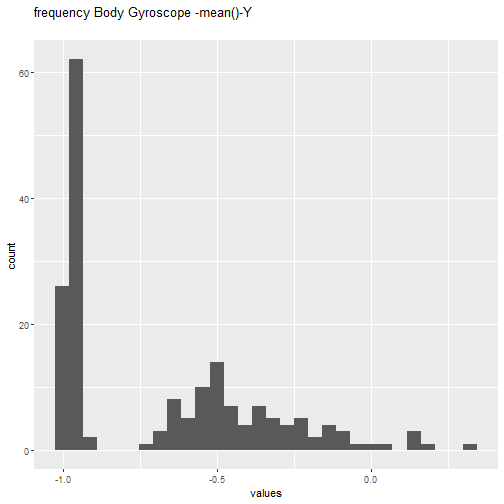

0 missing values.

#### Summary statistics

| name | data_type | missing | complete | n | mean | sd | p0 | p25 | p50 | p75 | p100 | hist |
| --- | --- | --- | --- | --- | --- | --- | --- | --- | --- | --- | --- | --- |
| frequency Body Gyroscope -mean()-Y | numeric | 0 | 180 | 180 | -0.68 | 0.33 | -0.99 | -0.97 | -0.81 | -0.45 | 0.33 | ▇▁▃▂▁▁▁▁ |

### frequency Body Gyroscope -mean()-Z

#### Distribution

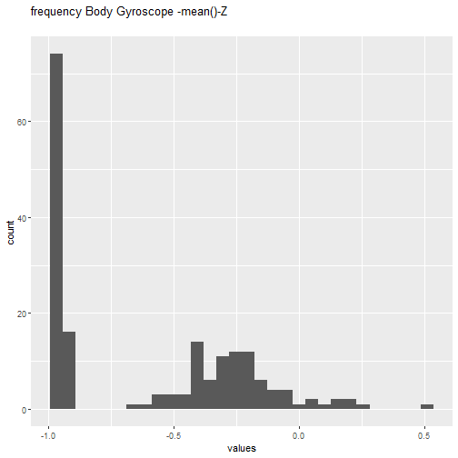

0 missing values.

#### Summary statistics

| name | data_type | missing | complete | n | mean | sd | p0 | p25 | p50 | p75 | p100 | hist |
| --- | --- | --- | --- | --- | --- | --- | --- | --- | --- | --- | --- | --- |
| frequency Body Gyroscope -mean()-Z | numeric | 0 | 180 | 180 | -0.6 | 0.38 | -0.99 | -0.96 | -0.79 | -0.26 | 0.49 | ▇▁▁▃▂▁▁▁ |

### frequency Body Gyroscope -std()-X

#### Distribution

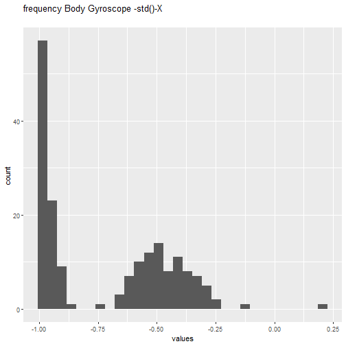

0 missing values.

#### Summary statistics

| name | data_type | missing | complete | n | mean | sd | p0 | p25 | p50 | p75 | p100 | hist |
| --- | --- | --- | --- | --- | --- | --- | --- | --- | --- | --- | --- | --- |
| frequency Body Gyroscope -std()-X | numeric | 0 | 180 | 180 | -0.71 | 0.27 | -0.99 | -0.98 | -0.81 | -0.48 | 0.2 | ▇▁▂▃▂▁▁▁ |

### frequency Body Gyroscope -std()-Y

#### Distribution

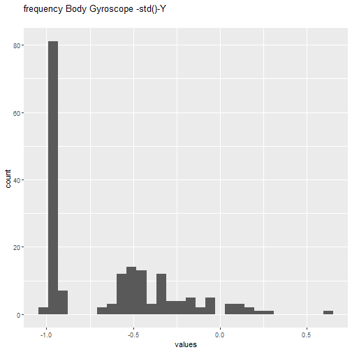

0 missing values.

#### Summary statistics

| name | data_type | missing | complete | n | mean | sd | p0 | p25 | p50 | p75 | p100 | hist |
| --- | --- | --- | --- | --- | --- | --- | --- | --- | --- | --- | --- | --- |
| frequency Body Gyroscope -std()-Y | numeric | 0 | 180 | 180 | -0.65 | 0.36 | -0.99 | -0.96 | -0.8 | -0.42 | 0.65 | ▇▁▃▂▁▁▁▁ |

### frequency Body Gyroscope -std()-Z

#### Distribution

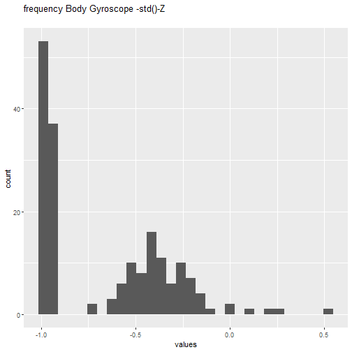

0 missing values.

#### Summary statistics

| name | data_type | missing | complete | n | mean | sd | p0 | p25 | p50 | p75 | p100 | hist |
| --- | --- | --- | --- | --- | --- | --- | --- | --- | --- | --- | --- | --- |
| frequency Body Gyroscope -std()-Z | numeric | 0 | 180 | 180 | -0.66 | 0.34 | -0.99 | -0.96 | -0.82 | -0.39 | 0.52 | ▇▁▃▃▁▁▁▁ |

### frequency Body Accelerometer Magnitude -mean()

#### Distribution

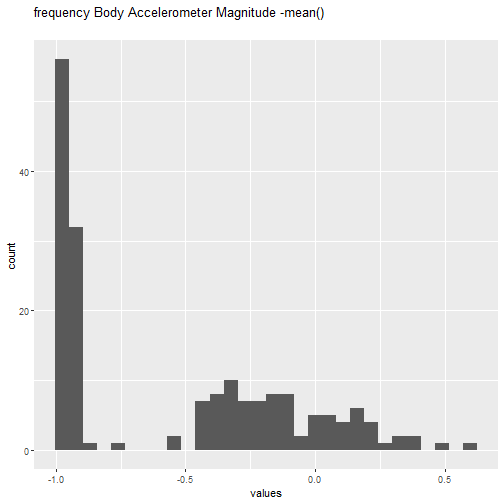

0 missing values.

#### Summary statistics

| name | data_type | missing | complete | n | mean | sd | p0 | p25 | p50 | p75 | p100 | hist |
| --- | --- | --- | --- | --- | --- | --- | --- | --- | --- | --- | --- | --- |
| frequency Body Accelerometer Magnitude -mean() | numeric | 0 | 180 | 180 | -0.54 | 0.45 | -0.99 | -0.96 | -0.67 | -0.16 | 0.59 | ▇▁▁▃▂▂▁▁ |

### frequency Body Accelerometer Magnitude -std()

#### Distribution

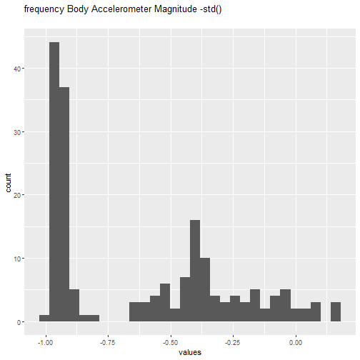

0 missing values.

#### Summary statistics

| name | data_type | missing | complete | n | mean | sd | p0 | p25 | p50 | p75 | p100 | hist |
| --- | --- | --- | --- | --- | --- | --- | --- | --- | --- | --- | --- | --- |
| frequency Body Accelerometer Magnitude -std() | numeric | 0 | 180 | 180 | -0.62 | 0.35 | -0.99 | -0.95 | -0.65 | -0.37 | 0.18 | ▇▁▁▂▂▁▁▁ |

### frequency BodyBody Accelerometer JerkMagnitude -mean()

#### Distribution

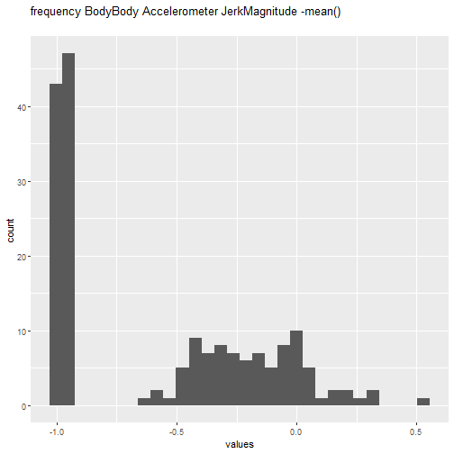

0 missing values.

#### Summary statistics

| name | data_type | missing | complete | n | mean | sd | p0 | p25 | p50 | p75 | p100 | hist |
| --- | --- | --- | --- | --- | --- | --- | --- | --- | --- | --- | --- | --- |
| frequency BodyBody Accelerometer JerkMagnitude -mean() | numeric | 0 | 180 | 180 | -0.58 | 0.43 | -0.99 | -0.98 | -0.79 | -0.19 | 0.54 | ▇▁▁▂▂▂▁▁ |

### frequency BodyBody Accelerometer JerkMagnitude -std()

#### Distribution

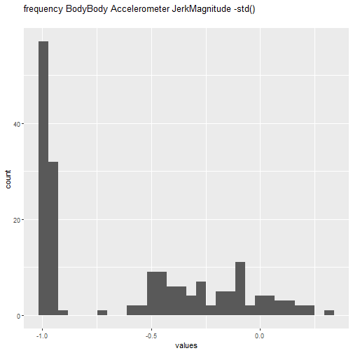

0 missing values.

#### Summary statistics

| name | data_type | missing | complete | n | mean | sd | p0 | p25 | p50 | p75 | p100 | hist |
| --- | --- | --- | --- | --- | --- | --- | --- | --- | --- | --- | --- | --- |
| frequency BodyBody Accelerometer JerkMagnitude -std() | numeric | 0 | 180 | 180 | -0.6 | 0.41 | -0.99 | -0.98 | -0.81 | -0.27 | 0.32 | ▇▁▁▂▁▂▁▁ |